# Modelling the innovation and extinction of archaeological ideas

Ben Marwick, University of Washington

Erik Gjesfjeld, University of Cambridge

26 January, 2018

Abstract

# 1 Introduction

The history of archaeology is often told as a sequence of prominent individuals and their publications. Due to the focus on big names and big papers, the diversity of archaeological publications is often underestimated. Here we introduce a quantitative method that illuminates historical trends in archaeological writing by investigating a large number of journal articles. We use a Bayesian framework developed for estimating speciation, extinction, and preservation rates from incomplete fossil data. We model archaeological ideas within this framework by equating citations of archaeological literature to occurrences in the fossil record. We obtained reference lists for 12,000 journal articles published between 1975 and 2017 and explored the chronological distribution of cited papers to identify periods of innovation and extinction. We discuss how our modeling approach helps to quantify the diversification of archaeological publications and our broader understanding about the history of archaeological thought.

# 2 Background

## 2.1 Basic exploration of the data

We have 12,133 articles in our study. The publication dates range from 1905 to 2017. The bibliographic data for these articles was obtained from a search of Clarivate Analytics Web of Science, using the keyword ‘archaeolog’ and filtering the results to keep only research articles.

The distribution of articles is strongly skewed to more recent years, with a rapid increase after the mid-2000s. For the rest of our analysis we’re going to limit the time frame to the 12,074 published during 1975-2017 because the data from before 1975 is incomplete for some key journals, such as *American Antiquity*.

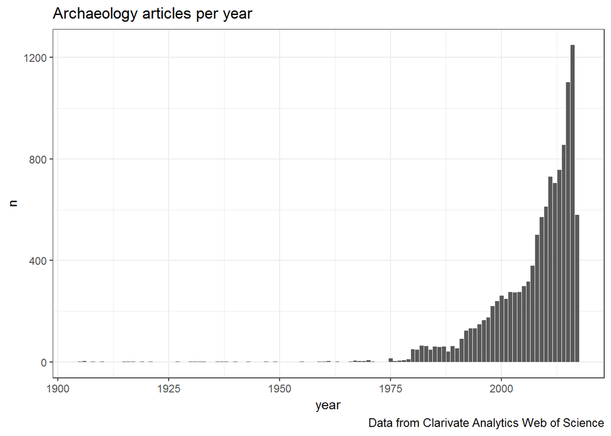

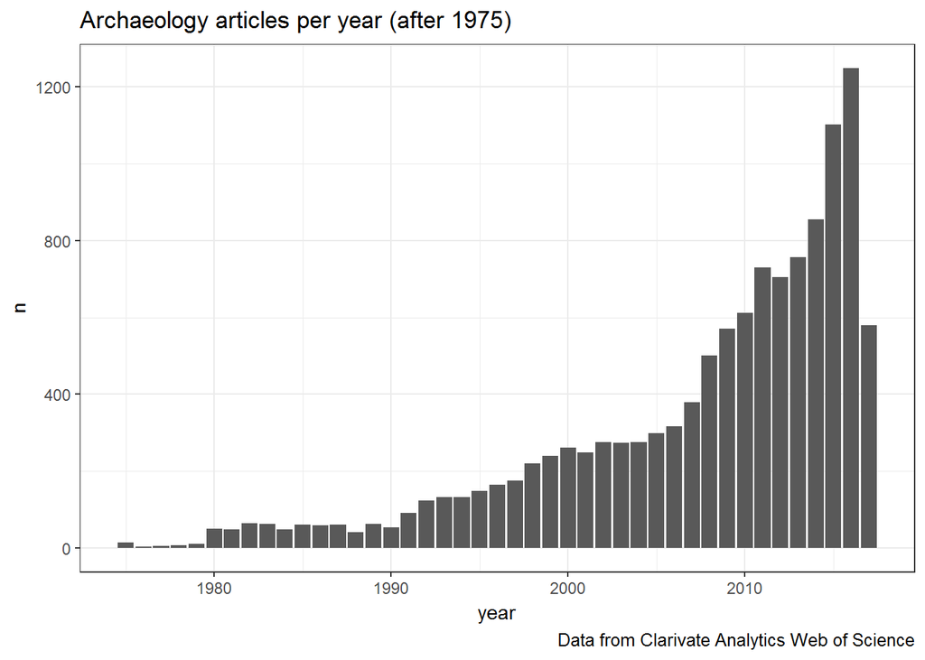

Let’s look at the citations in each of these articles. As expected, the number of citations per year closely follows the distribution of articles per year.

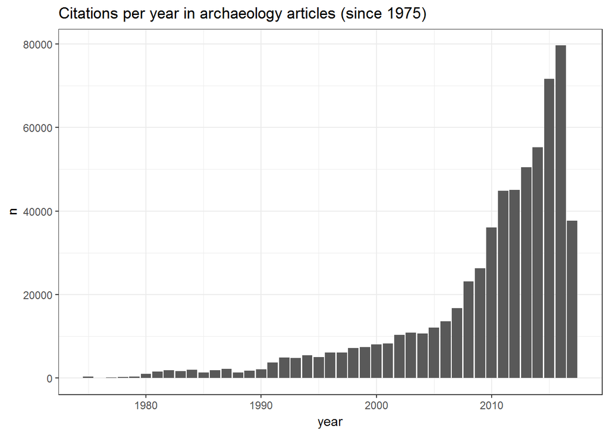

With such a large data set we can answer a few basic interesting questions, for example:

- What is the most cited paper?
- What is the most cited paper per decade?

Here are the top ten most cited items overall:

| .out | n |
| --- | --- |
| BOURDIEU PIERRE 1977 OUTLINE THEORY PRACT | 198 |
| TILLEY C 1994 PHENOMENOLOGY LANDSC | 181 |
| REIMER PJ 2009 RADIOCARBON V51 P1111 | 136 |
| SCHIFFER M B 1987 FORMATION PROCESSES | 136 |
| REIMER PJ 2013 RADIOCARBON V55 P1869 | 127 |
| TRIGGER B G 1989 HIST ARCHAEOLOGICAL | 127 |
| REIMER PJ 2004 RADIOCARBON V46 P1029 | 120 |
| INGOLD T 2000 PERCEPTION ENV ESSAY | 119 |
| BINFORD L 1981 BONES ANCIENT MEN MO | 116 |
| LATOUR B 2005 REASSEMBLING SOCIAL | 110 |

And here are the most cited items per decade (there is a tie for the 1970-1980 data):

| decade | .out | n |
| --- | --- | --- |
| 2010-2020 | BOURDIEU PIERRE 1977 OUTLINE THEORY PRACT | 140 |
| 2000-2010 | STUIVER M 1998 RADIOCARBON V40 P1041 | 80 |
| 1990-2000 | TRIGGER B G 1989 HIST ARCHAEOLOGICAL | 46 |
| 1980-1990 | CLARKE D L 1968 ANAL ARCHAEOLOGY | 22 |
| 1970-1980 | CLARKE D L 1972 MODELS ARCHAEOLOGY | 2 |
| 1970-1980 | LAPP PW 1969 BIBLICAL ARCHAEOLOGY | 2 |
| 1970-1980 | SCOLLAR I 1975 12 COUNC BRIT ARCH R P52 | 2 |
| 1970-1980 | WINTERS HOWARD D 1968 NEW PERSPECTIVES ARC P175 | 2 |

We can zoom in on one article, Binford’s “Archaeology as Anthropology”, published in 1962. The plot shows the proportion of all citations in each year that are Binford 1962.

We can model rates of extinction using tools from palaeontology.

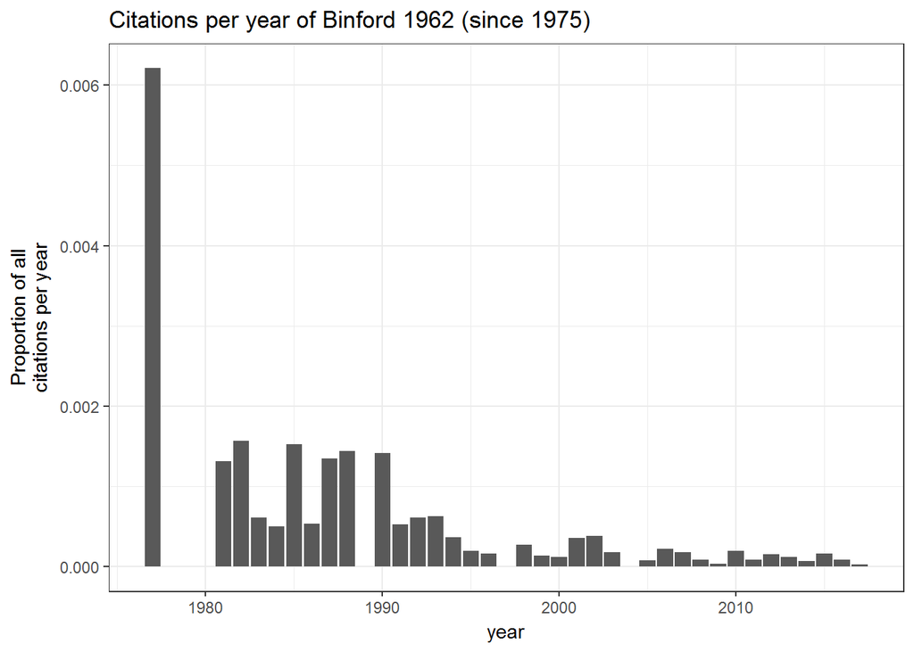

# 3 Innovation and extinction rate modelling

## 3.1 Preparing the data

### 3.1.1 Setting the time unit

These citation data are structured so that we have multiple dates of occurance for each paper. We call this an ‘occurrence data’ set (as we have dates for each individual occurrence), which can be contrasted with a ‘lineage’ data set where we’d have only the dates of the first and last instance of each article.

To compute extinction and innovation rates on these data we must change the time scale so that 0 is the most recent time unit and the higher the number the further back in time.

### 3.1.2 Formatting Ocurrence Data for PyRate

From https://www.nature.com/articles/palcomms201619 :

Data sets in occurrence format, such as we have here, provide the opportunity to incoporate uncertainty about the preservation of the observations when analyzing origination and extinction rates. If a researcher does not have a high level of certainty that the dates of first and last occurrence are correct, such as is often the case with fossils or artifacts, preservation can be informative.

We need a data frame with four columns:

Species: which refers the smallest taxonomic unit, here this is each cited reference. In an archaeological context this would be something like a pottery sherd.

Status: which identifies whether the reference is still used today, we will consider all to be ‘extinct’. This would also be true of archaeological artefacts.

```
#> # A tibble: 6 x 4
#> # Groups:   Species [6]
#>   Species                                           Status min_age max_age
#>   <chr>                                             <chr>    <dbl>   <dbl>
#> 1 BANG G 1970 ACTA ODONTOL SCAND V28 P3 DOI 103109~ extin~    1986    2011
#> 2 CLUTTONBROCK J 1981 DOMESTICATED ANIMALS          extin~    1984    2017
#> 3 GOODMAN AH 1980 HUM BIOL V52 P515                 extin~    1986    2014
#> 4 HILLSON S 1986 TEETH                              extin~    1986    2012
#> 5 HILLSON SW 1979 WORLD ARCHAEOL V11 P147           extin~    1986    2014
#> 6 ADAMS WY 1979 CURR ANTHROPOL V20 P727 DOI 101086~ extin~    1986    2011
```

We can make a histogram showing the distribution of the number of years each cited article was cited for (article lifespan):

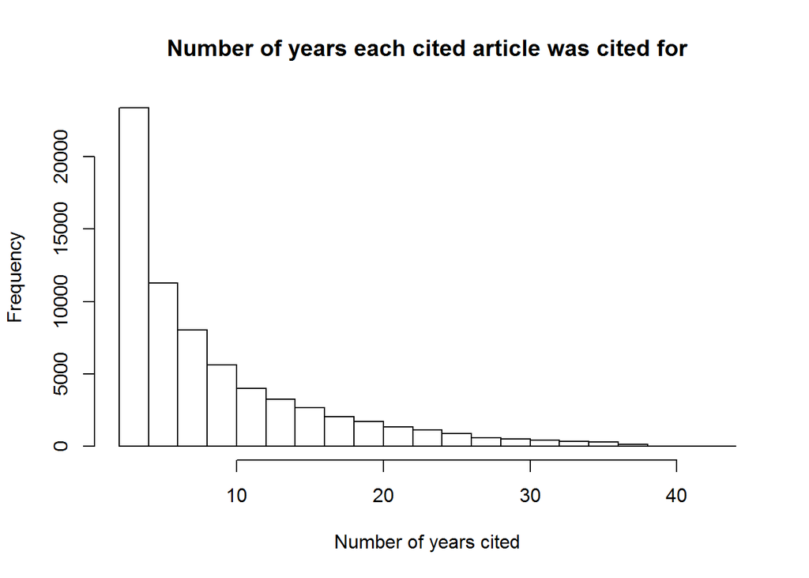

And what about the paper published in each 5-year interval of our data that has been cited over the longest duration? In fact there are many ties here, so we’ve just randomly sampled from each 5 year interval.

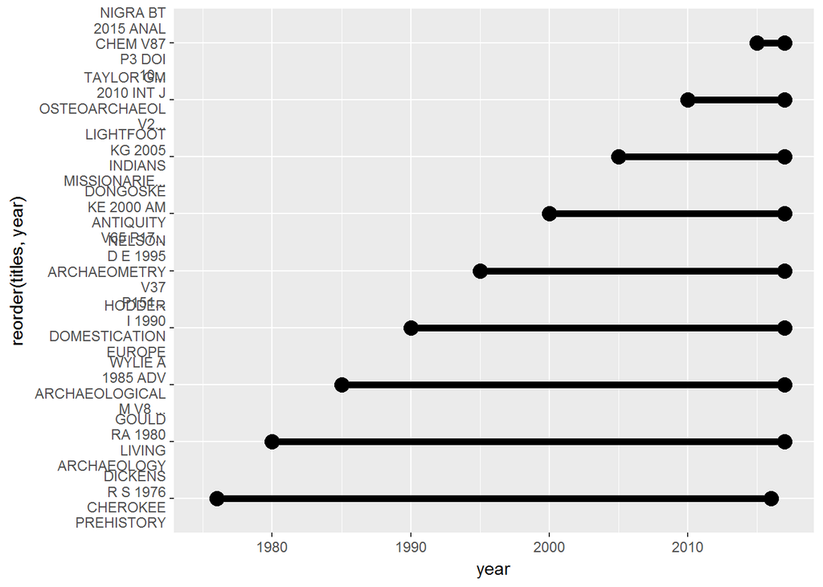

## 3.2 Bayesian estimation of diversification

From https://www.nature.com/articles/palcomms201619:

The diversification of citations through time is modelled here as the product of both origination and extinction. The estimation of origination and extinction rates utilizes an underlying birth–death model, which assumes these processes are random events occurring through continuous time. The probability of events occurring at any given time is determined by parameters of the birth–death process, which express the expected number of origination (or extinction) events per lineage per units of time. Rates can vary through time by introducing rate shifts (Silvestro et al., 2014b; Stadler, 2011; Stadler, 2012).

The first year that an article is cited is considered as an origination event, with the last year it was cited is characterized as an extinction event. To speed up the computations we will convert the *occurance* format to a *lineage* format, where each cited item only appears once in the table with its earliest and latest years of citation.

The next step is to prepare this occurance data frame for input into Python to compute estimations of the origination, extinction and preservation rates. This is accomplished by calling the `extract.ages` function which extracts the ages and creates a readable python file:

```
#> $species_pyrate_data
#>   clade species ts te
#> 1     0       1 35 24
#> 2     0       2 29 26
#> 3     0       3 29 26
#> 4     0       4 21 18
#> 5     0       5  4  1
#> 6     0       6 10  8
#>
#> $fixed_clade_key
#> # A tibble: 1 x 3
#>   Names `ID Number` Count
#>   <fct>       <dbl> <int>
#> 1 NA           1.00 67729
#>
#> $fixed_species_key
#>                                                                                                                              Names
#> 1                                                                                                        1976 ISTORIZM ARKHEOLOGII
#> 2                                                                                                            1979 KAOGU XUEBAO P27
#> 3                                                                                                         1979 SHAANXI CHUTU SHANG
#> 4                                                                                                            1995 NATURE V377 P372
#> 5                                       Å¤Æ£Æ¥ XIA ZHENGJIE 2008 Ç¬¬ÅÇºªÇ Ç© QUATERNARY SCIENCES V28 P96
#> 6 ÅÄ¸Ç LIU TUNGSHENG 2006 Ç¬¬ÅÇºªÇ Ç© QUATERNARY SCIENCES V26 P673
#>   ID Number
#> 1         1
#> 2         2
#> 3         3
#> 4         4
#> 5         5
#> 6         6
```

We write a text file to be used with the PyRate analysis later on. This file will appear in our current working directory

A python file titled `lineage_pyrate_data_PyRate.py` should have been created and available in the working directory.

# 4 Summary Plots

Prior to starting the PyRate analysis, it is good practice to get a sense of the data by developing a series of plots. Using the function below, the following plots are created

1. Log Lineages Through Time
2. Cumulative Diversity Through Time
3. Average Lifespan Through Time
4. Histogram of Lifespans

### 4.0.1 Citation Data (Lineage Data)

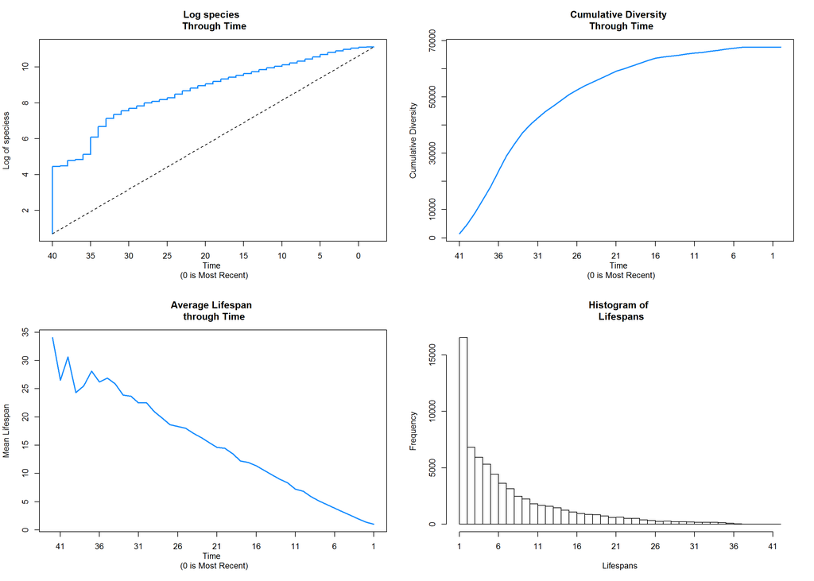

### 4.0.2 Choosing the best underlying model

From https://www.nature.com/articles/palcomms201619 :

The first decision to be made in the analysis of cultural data is whether a birth-death model is an appropriate model for the data under analysis. In this analysis, a birth-death model refers to a continuous-time Markov process where in each time step a the unit of analysis (typically a lineage or new product) can either originate (birth) or go extinct (death). Being that the birth-death model is an example of a continuous-time Markov process, the emergence or discontinuation of a lineage in the future depends on the current state of the model in the previous time step. In PyRate, if a birth-death model is favored, this means that the origination or extinction of a cultural lineage or material culture product is influenced by the existing number of lineages in the previous time step. This can be seen as suggestive of incremental innovation where the emergence of a new lineage or product is strongly influenced by the previous lineage or products available, likely through minor modifications of existing traits. A birth-death model is generally suggestive of a strong inheritance pattern between generations of cultural lineages or artifacts. (For example, a new car model that is a combination of traits from other already existing car models).

In contrast to many biological systems, where birth-death models have been shown to be very reliable, it is not always known if a birth-death model is appropriate for cultural data. An alternative model, developed for this research, is an immigration-death model. In this model, the emergence or discontinuation of a lineage or product is independent of the previous states of the model. This models has an underlying Poisson distribution which highlights that the emergence or discontinuation of a cultural lineage or product would occur randomly in each time step. This can be seen as suggestive of more radical innovation or horizontal transmission of traits from individuals or technologies from outside of the direct lineages. (For example, a new car model that has novel traits that were developed in the airline industry).

In order to test between these two models, the data set will be analyzed in two separate analysis using the mBDI function In order to execute the analysis, the following commands will execute Python code. You need to have Python 2.7 installed for this to work. You can download this from https://www.python.org/. You will also need numpy and scipy for your Python installation. The `mBDI` function will try to guess where Python is on you computer, but if it guesses wrong and return an error, you may need to set the `path_to_python` argument to the `mBDI` function to ensure that it can find where Python is installed on your computer. See `?mBDI` for more details.

Upon executing these commands, a new folder will be created in your working directory called `pyrate_mcmc_logs`.

This analysis uses the default settings of samples every 1,000 generations for 10,000,000 generations. Details about changes to PyRate default settings can be found in Silvestro et al. 2014. If access to a computing cluster is available, this is the preferred option. To reduce the run time of the analysis, simply adjust the number of generations from 10 million to 1 million.

# 5 Visualizing the Rates of Origination and Extinction

These plots will use the default plot setting in PyRate and create both an R file and pdf with the rate-through-time plots. Open the pdf and check out the rates of origination and extinction through time!

We can redraw these plots in R:

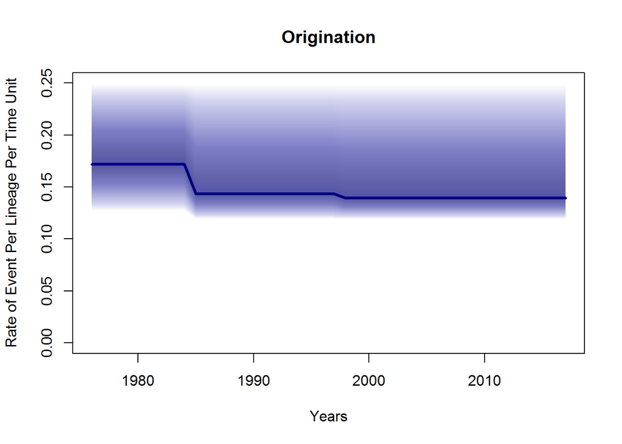

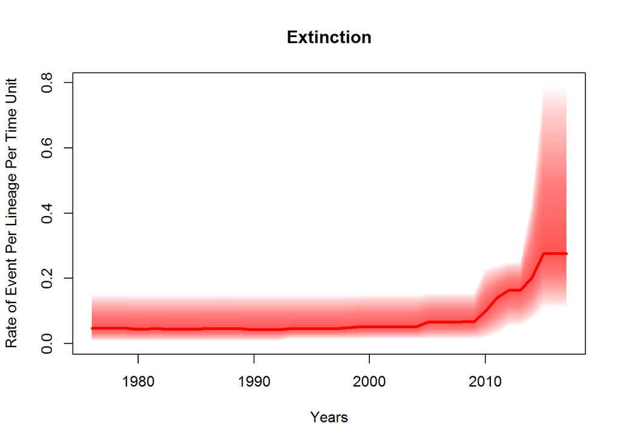

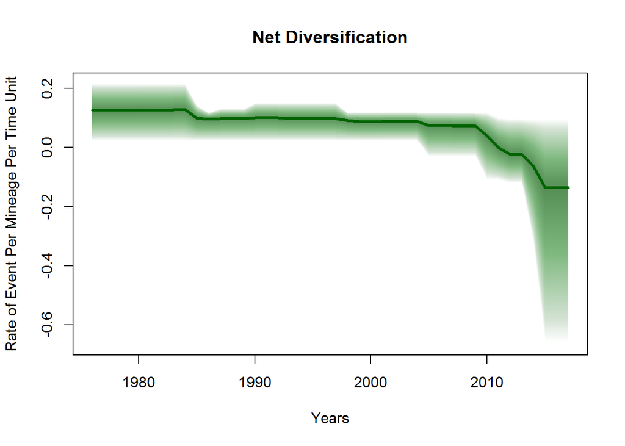

# 6 Model testing between the BD/ID models

It is important to note that we are unable to quantitatively test whether a birth-death or immigration-death model best fits our data from the plotting of origination, extinction and net diversification rates. In order to identify the best-fitting model we need to model test between all the most likely models.

The input file paths are:

pyrate_mcmc_logs/occurrence_pyrate_data_1BD_mcmc.log pyrate_mcmc_logs/occurrence_pyrate_data_1ID_mcmc.log pyrate_mcmc_logs/lineage_pyrate_data_1BD_mcmc.log pyrate_mcmc_logs/lineage_pyrate_data_1ID_mcmc.log

PyRate will provide a breakdown of the probability of most likely rate models for both speciation and extinction. In addition the best configuration of rates of also provided. It is probably best to open a spreadsheet (excel or Google sheets) and record these values.

# 7 Methods

# 8 Results

# 9 Discussion

# 10 Conclusion

# 11 Acknowledgements

# 12 References

### 12.0.1 Colophon

This report was generated on 2018-01-26 18:58:32 using the following computational environment and dependencies:

[output not shown]

[output cut: 108 more lines]

```
#>  Github (rstudio/rstudioapi@109e593)
#>  CRAN (R 3.4.0)
#>  Github (hadley/scales@d767915)
#>  local
#>  CRAN (R 3.4.2)
#>  CRAN (R 3.4.0)
#>  CRAN (R 3.4.3)
#>  CRAN (R 3.4.2)
#>  CRAN (R 3.4.3)
#>  local
#>  CRAN (R 3.4.3)
#>  local
#>  Github (jimhester/withr@df18523)
#>  CRAN (R 3.4.1)
#>  CRAN (R 3.4.3)
```

The current Git commit details are:

```
#> Local:    master D:/My Documents/My Papers/conferences/SAA2018/modelextinctionideas/
#> Remote:   master @ origin (https://github.com/benmarwick/modelextinctionideas)
#> Head:     [fc7c72e] 2018-01-23: got some plots
```